# Introduction to Python Project : FoodHub Data Analysis

## Problem Statement

### Context

FoodHub is a food aggregator company in Newyork city, that offers access to multiple restaurants through a single smartphone app. Customer places order on app and app takes care of informing restarents, assigning delivery partner to pick up and deliver the order, customer can rate the order in the app. FoodHub earns money by collecting a fixed margin on the delivery order from the restaurants.

### Dataset

Dataset for analysis includes below columns order_id, customer_id, restarent_name, cuisine_type, cost_of_the_order,day_of_the_week, rating, food_preparation_time, delivery_time

#### Key Qustions to be answered

- How many rows and columns are present in the data?
- What are the datatypes of the different columns in the dataset?
- Are there any missing values in the data? If yes, how will they be treated?
- What insights can be drawn from statistical summaries of the data?
- Which restaurants and cuisines are most popular?
- How to identify top customers and frequent restaurant partners?
- What are the notable trends in order costs and delivery times?

### Objective

The objective is to get fair idea about the demand of different restaurants which will help the company enhance customer experience.

### Data Dictionary

1. order_id - Unique ID of the order
2. customer_id - Unique ID of the customer
3. restaurant_name - Name of the restaurant
4. cuisine_type - Cuisine ordered by the customer
5. cost_of_the_order - Cost of the order
6. day_of_the_week - Weekday or Weekend
7. rating - Rating given by customer out of 5
8. food_preparation_time - Time taken by restaurants to prepare the food.
9. delivery_time - Time taken by delivery person to deliver the food.

### Let us start by importing the required libraries

```python
# import necessary libraries for the project
import pandas as pd
import numpy as np
import math
import matplotlib.pyplot as plt
import seaborn as sns
%matplotlib inline
import warnings
warnings.filterwarnings('ignore')
```

### Understanding the structure of the data

```python
#from Google Colab to drive
from google.colab import drive
drive.mount('/content/drive')
```

```python
# read the data
#df = pd.read_csv('/content/drive/My Drive/Great learning/Introduction to Python/FoodHub/foodhub_order.csv')
df=pd.read_csv('foodhub_order.csv')
```

```python
# view the first 5 rows
df.head()
```

[output not shown]

### **Question 1:** How many rows and columns are present in the data?

```python
# find shape of data
df.shape
```

```
(1898, 9)
```

#### Observations:

There are 1898 rows and 9 columns in data.

### **Question 2:** What are the datatypes of the different columns in the dataset? (The info() function can be used)

```python
# find data types of data
df.info()
```

```
<class 'pandas.core.frame.DataFrame'>
RangeIndex: 1898 entries, 0 to 1897
Data columns (total 9 columns):
 #   Column                 Non-Null Count  Dtype
---  ------                 --------------  -----
 0   order_id               1898 non-null   int64
 1   customer_id            1898 non-null   int64
 2   restaurant_name        1898 non-null   object
 3   cuisine_type           1898 non-null   object
 4   cost_of_the_order      1898 non-null   float64
 5   day_of_the_week        1898 non-null   object
 6   rating                 1898 non-null   object
 7   food_preparation_time  1898 non-null   int64
 8   delivery_time          1898 non-null   int64
dtypes: float64(1), int64(4), object(4)
memory usage: 133.6+ KB
```

#### Observations:

- order_id is integer type and has no null values.
- customer_id is integer type and has no null values.
- restaurant_name is object type and has no null values.
- cuisine_type is object type and has no null values.
- cost_of_the_order is float type and has no null values.
- day_of_the_week is object type and has no null values.
- rating is object type and has no null values.
- food_preparation_time is integer type and has no null values.
- delivery_time is integer type and has no null values.

### **Question 3:** Are there any missing values in the data? If yes, treat them using an appropriate method.

We already know there are no null values in data However there are some rows with rating = "Not given"

```python
# Find if there are any rows that do not have numerical value for rating column
df.isnull().sum().sum()
```

```
0
```

```python
df_complete = df.copy()
df_complete.loc[df['rating'] == 'Not given','rating'] = np.nan
rating_not_given = df_complete.isnull().sum()
rating_not_given
```

```
order_id                   0
customer_id                0
restaurant_name            0
cuisine_type               0
cost_of_the_order          0
day_of_the_week            0
rating                   736
food_preparation_time      0
delivery_time              0
dtype: int64
```

```python
# fill null values in rating with mode
df_complete['rating'].fillna(df_complete['rating'].mode()[0])
```

```
0       5
1       5
2       5
3       3
4       4
       ..
1893    5
1894    5
1895    5
1896    5
1897    5
Name: rating, Length: 1898, dtype: object
```

### **Question 4:** Check the statistical summary of the data. What is the minimum, average, and maximum time it takes for food to be prepared once an order is placed?

```python
# check statistical summary of data
df_complete.describe().T
```

|  | count | mean | std | min | 25% | 50% | 75% | max |
| --- | --- | --- | --- | --- | --- | --- | --- | --- |
| order_id | 1898.0 | 1.477496e+06 | 548.049724 | 1476547.00 | 1477021.25 | 1477495.50 | 1.477970e+06 | 1478444.00 |
| customer_id | 1898.0 | 1.711685e+05 | 113698.139743 | 1311.00 | 77787.75 | 128600.00 | 2.705250e+05 | 405334.00 |
| cost_of_the_order | 1898.0 | 1.649885e+01 | 7.483812 | 4.47 | 12.08 | 14.14 | 2.229750e+01 | 35.41 |
| food_preparation_time | 1898.0 | 2.737197e+01 | 4.632481 | 20.00 | 23.00 | 27.00 | 3.100000e+01 | 35.00 |
| delivery_time | 1898.0 | 2.416175e+01 | 4.972637 | 15.00 | 20.00 | 25.00 | 2.800000e+01 | 33.00 |

```python
# check statistical summary of categorical columns
df_complete.describe(include=object).T
```

|  | count | unique | top | freq |
| --- | --- | --- | --- | --- |
| restaurant_name | 1898 | 178 | Shake Shack | 219 |
| cuisine_type | 1898 | 14 | American | 584 |
| day_of_the_week | 1898 | 2 | Weekend | 1351 |
| rating | 1162 | 3 | 5 | 588 |

#### Observations:

- There are 178 unique restaurants out of that restaurant "Shake Shack" is on top with 219 orders.
- There are 14 different cuisine types out of that "American" cuisine is on top with 584 orders.
- For day_of_the_week there are two values weekday and weekend, out of these weekend is on top with 1351 orders.
- For rating there are 3 unique values 3,4,5 out of these 5 is on top with 588 orders rated 5.
- Minimum food preparation time is 20 minutes.
- In general food is prepared within 27 minutes give or take 5 minutes.
- Maximum food preparation time is 35 minutes.
- Minimum delivery time is 15 minutes.
- In general food is delivered within 24 minutes give or take 5 minutes.
- Maximum delivery time is 33 minutes.
- Minimum order cost is 4.47 dollers.
- In general cost of order is 16.5 dollers give or take 7.4 dollers.
- Maximum order cost is 35.41 dollers

### **Question 5:** How many orders are not rated?

```python
# Find if there are any rows that do not have numerical value for rating column
rating_not_given
```

```
order_id                   0
customer_id                0
restaurant_name            0
cuisine_type               0
cost_of_the_order          0
day_of_the_week            0
rating                   736
food_preparation_time      0
delivery_time              0
dtype: int64
```

#### Observations:

- 736 orders are not rated.

### Exploratory Data Analysis (EDA)

### **Question 6:** Explore all the variables and provide observations on their distributions. (Generally, histograms, boxplots, countplots, etc. are used for univariate exploration.)

#### cost of the order

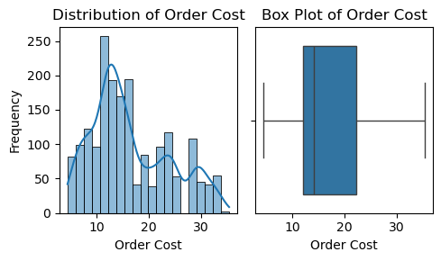

```python
# Create subplots
fig, axes = plt.subplots(1, 2, figsize=(5, 3)) # 1 row, 2 columns
# Histogram: To see the distribution of order costs.
sns.histplot(data = df_complete, x='cost_of_the_order', bins=20, kde=True, ax=axes[0])
axes[0].set_title('Distribution of Order Cost')
axes[0].set_xlabel('Order Cost')
axes[0].set_ylabel('Frequency')
#Box Plot: To detect outliers and visualize the spread of the data.
sns.boxplot(data=df_complete, x='cost_of_the_order', ax=axes[1])
axes[1].set_title('Box Plot of Order Cost')
axes[1].set_xlabel('Order Cost')
plt.tight_layout() # Adjust layout to prevent overlapping
plt.show()
```

- Maximum number of orders are placed with cost 11 to 13 dollers.
- Number of orders decreases as cost of order increases, indicating a trend among customers to order more within a manageabe cost.
- There are no outliers in order cost, indicating no customer has placed an order with much more higher cost.
- The distribution is little bit right skewed, indicating most customers prefer to order within cost range of 11 to 15 dollers while maximum cost can go above 30 dollers.
- There are three modes in the distribution, indicating there are multiple cost price that customers prefer while ordering food.

#### rating

rating is a categorical column.

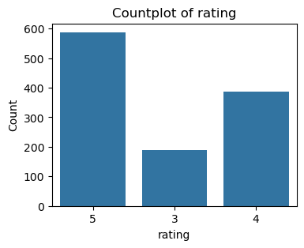

```python
# make count plot of rating
plt.figure(figsize=(4, 3))
sns.countplot(x='rating', data=df_complete)
plt.title('Countplot of rating')
plt.xlabel('rating')
plt.ylabel('Count')
plt.show()
```

#### food preparation time

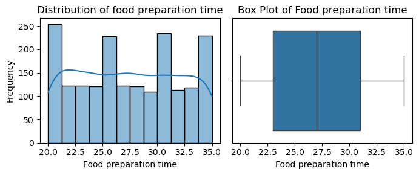

```python
# Create subplots
fig, axes = plt.subplots(1, 2, figsize=(7, 3)) # 1 row, 2 columns
# Histogram: To see the distribution of order costs.
sns.histplot(data=df_complete, x='food_preparation_time', kde=True, ax=axes[0])
axes[0].set_title('Distribution of food preparation time')
axes[0].set_xlabel('Food preparation time')
axes[0].set_ylabel('Frequency')
#Box Plot: To detect outliers and visualize the spread of the data.
sns.boxplot(data=df_complete, x='food_preparation_time', ax=axes[1])
axes[1].set_title('Box Plot of Food preparation time')
axes[1].set_xlabel('Food preparation time')
plt.tight_layout() # Adjust layout to prevent overlapping
plt.show()
```

- Distribution of food preparation time is uniform, indicating most orders take similar time to get prepared.
- There are no outliers, indicating no order took a lot of time to get prepared, which is good.
- All orders get ready between 20 to 35 minutes.

#### Delivery time

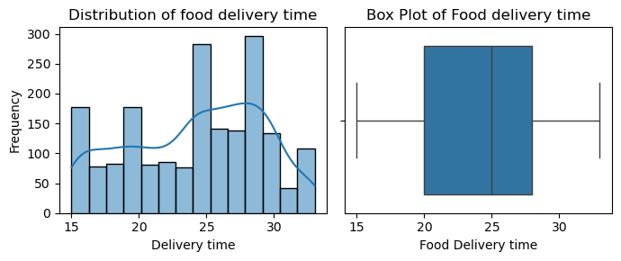

```python
# Create subplots
fig, axes = plt.subplots(1, 2, figsize=(7, 3)) # 1 row, 2 columns
# Histogram: To see the distribution of order costs.
sns.histplot(data=df_complete, x='delivery_time', kde=True, ax=axes[0])
axes[0].set_title('Distribution of food delivery time')
axes[0].set_xlabel('Delivery time')
axes[0].set_ylabel('Frequency')
#Box Plot: To detect outliers and visualize the spread of the data.
sns.boxplot(data=df_complete, x='delivery_time', ax=axes[1])
axes[1].set_title('Box Plot of Food delivery time')
axes[1].set_xlabel('Food Delivery time')
plt.tight_layout() # Adjust layout to prevent overlapping
plt.show()
```

- Distribution is almost uniform with a little bit of hump between 22 to 29 minutes, indicating more number of orders geting delivered between 22 to 29 minutes.
- There are no outliers, indicating no order took a lot of time to get delivered, which is good.

#### restaurant name

restaurant_name is a categorical data column with lot of different restaurants.

```python
# find out unique restaurants count
df_complete['restaurant_name'].nunique()
```

```
178
```

- There are 178 different restaurants.
- Its difficult to visualise data of so many different restaurants so let us categorise it into differnet categories based on no of orders recieved.

```python
# Step 1: Calculate count of orders in each category
restarant_category_counts = df_complete['restaurant_name'].value_counts()

# Step 2: Define bins based on the counts - here's an example of using quantiles
restaurant_bin_edges = [1, 10, 50, 100, float('inf')]
restaurant_labels = ['Low', 'Medium', 'High', 'Very High']

restaurant_bins = pd.cut(restarant_category_counts, bins=restaurant_bin_edges, labels=restaurant_labels, right=False)

# Step 3: Create a new DataFrame to map original categories to the new bins
restaurant_category_groups = pd.DataFrame({'Category': restarant_category_counts.index, 'Counts': restarant_category_counts.values, 'restaurant_with_no_of_orders': restaurant_bins.values})

# Step 4: Merge this with your original data, if needed
restarant_data_df = df_complete.merge(restaurant_category_groups[['Category', 'restaurant_with_no_of_orders']], left_on='restaurant_name', right_on='Category', how='left').drop('Category', axis=1)

# Display the updated DataFrame
restarant_data_df.head(2)
```

[output not shown]

```python
# find out how many restaurants are in each category
restaurant_bin_counts = restaurant_bins.value_counts()
restaurant_bin_counts.index.name = 'restaurant_with_no_of_orders'
restaurant_bin_counts.name = 'count'
restaurant_bin_counts
```

```
restaurant_with_no_of_orders
Low          137
Medium        34
High           4
Very High      3
Name: count, dtype: int64
```

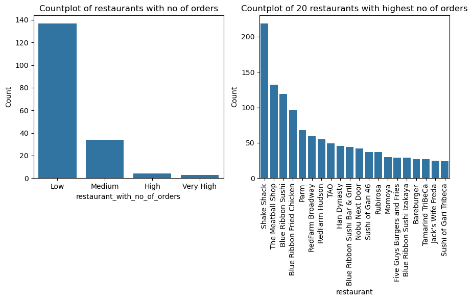

```python
# find out which are 20 restaurants with high number of orders
sr_imp_restaurant = df_complete['restaurant_name'].value_counts().sort_values(ascending=False).head(20)
df_imp_restaurant_counts = sr_imp_restaurant.reset_index()
df_imp_restaurant_counts.columns = ['restaurant', 'count']

df_bin_restaurant_counts = restaurant_bin_counts.reset_index()
df_bin_restaurant_counts.columns = ['restaurant_with_no_of_orders', 'count']

# Create subplots
fig, axes = plt.subplots(1, 2, figsize=(9, 6)) # 1 row, 2 columns
sns.barplot(x='restaurant_with_no_of_orders', y='count', data=df_bin_restaurant_counts, ax=axes[0])
axes[0].set_title('Countplot of restaurants with no of orders')
axes[0].set_xlable = 'Restaurants'
axes[0].set_ylabel('Count')


ax1 = sns.barplot(x='restaurant', y='count', data=df_imp_restaurant_counts, ax=axes[1])
axes[1].set_title('Countplot of 20 restaurants with highest no of orders')
axes[1].set_xlable = 'Restaurants'
axes[1].set_ylabel('Count')
plt.xticks(rotation=90)


plt.tight_layout() # Adjust layout to prevent overlapping
plt.show()
```

- There are total 178 different restaurants.
- 137 restaurants have searved less than or equal to 9 orders, indicating most restaurants have served less than or equal to 9 orders.
- 34 restaurants have searved 10 to 49 orders, indicating a good amount of orders belong to this category of restaurants.
- 4 restaurants have searved 50 to 99 orders, indicating thease 4 restaurants are doing really good.
- 3 restaurants have searved more than or equal to 100 orders, indicating thease 3 restaurants are doing very good.
- Restaurant "Shake Shack" has more than 210 orders which is maximum among all restaurants followed by "The meatball shop restaurant".

#### cuisine type

cuisine_type is categorical data column.

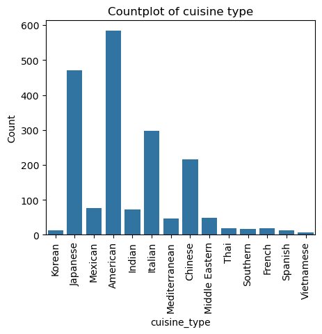

```python
# count plot of cuisine type
plt.figure(figsize=(5,4))
sns.countplot(data=df_complete, x='cuisine_type')
plt.title('Countplot of cuisine type')
plt.xlable = 'cuisine type'
plt.ylabel('Count')
plt.xticks(rotation=90)
plt.show();
```

- Around 590 orders are for American cuisine, which is most popular followed by Japanese cuisine with around 480 orders.

#### day of the week

day_of_the_week is categorical data column.

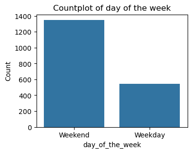

```python
#count plot of day of the week
plt.figure(figsize=(4,3))
sns.countplot(data=df_complete, x='day_of_the_week')
plt.title('Countplot of day of the week')
plt.xlable = 'day of the week'
plt.ylabel('Count')

plt.show();
```

- More than 1350 orders came during Weekends, while more than 500 orders came during weekdays, indicating busy weekends.

#### customer id

customer_id is categorical column in data.

```python
# find out how many unique customers are there
count_unique_customers = df_complete['customer_id'].nunique()
print(f"There are {count_unique_customers} different customers")
```

```
There are 1200 different customers
```

- There are 1200 different customers.
- Its dificult to visualise so many entries. Let us categorize these customers into 'Low', 'Medium', 'High', 'Very High' based on no of orders.

```python
# Step 1: Calculate count of orders in each category
category_counts = df_complete['customer_id'].value_counts()

# Step 2: Define bins based on the counts - here's an example of using quantiles
bin_edges = [1, 2, 5, 10, float('inf')]
labels = ['Low', 'Medium', 'High', 'Very High']

bins = pd.cut(category_counts, bins=bin_edges, labels=labels, right=False)

# Step 3: Create a new DataFrame to map original categories to the new bins
category_groups = pd.DataFrame({'Category': category_counts.index, 'Counts': category_counts.values, 'customer_with_no_of_orders': bins.values})

# Step 4: Merge this with your original data, if needed
customer_restaurant_order_df = restarant_data_df.merge(category_groups[['Category', 'customer_with_no_of_orders']], left_on='customer_id', right_on='Category', how='left').drop('Category', axis=1)

# Display the updated DataFrame
customer_restaurant_order_df.head(2)
```

[output not shown]

```python
# find out how many customers are there in each category
bin_counts = bins.value_counts()
bin_counts.index.name = 'customer_with_no_of_orders'
bin_counts.name = 'count'
bin_counts
```

```
customer_with_no_of_orders
Low          784
Medium       383
High          31
Very High      2
Name: count, dtype: int64
```

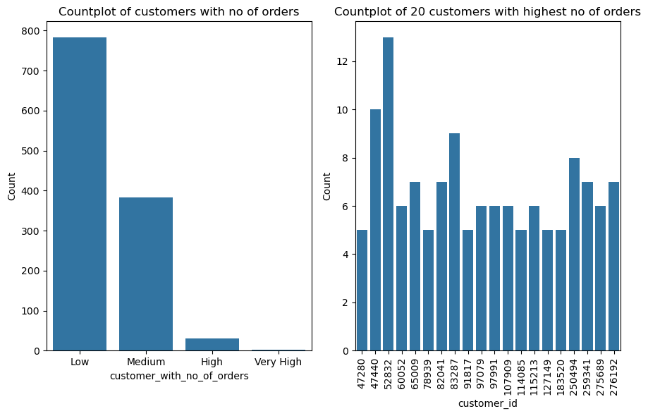

```python
df_bin_cust_counts = bin_counts.reset_index()
df_bin_cust_counts.columns = ['customer_with_no_of_orders', 'count']

# find out 20 customers with most number of orders
sr_imp_cust = df_complete['customer_id'].value_counts().sort_values(ascending=False).head(20)
df_imp_cust_counts = sr_imp_cust.reset_index()
df_imp_cust_counts.columns = ['customer_id', 'count']

# Create subplots
fig, axes = plt.subplots(1, 2, figsize=(9, 6)) # 1 row, 2 columns
sns.barplot(x='customer_with_no_of_orders', y='count', data=df_bin_cust_counts, ax=axes[0])
axes[0].set_title('Countplot of customers with no of orders')
axes[0].set_xlable = 'Customers'
axes[0].set_ylabel('Count')

# barplot of customers with high number of orders
ax1 = sns.barplot(x='customer_id', y='count', data=df_imp_cust_counts, ax=axes[1])
axes[1].set_title('Countplot of 20 customers with highest no of orders')
axes[1].set_xlable = 'Customers'
axes[1].set_ylabel('Count')
plt.xticks(rotation=90)

plt.tight_layout() # Adjust layout to prevent overlapping
plt.show()
```

#### order id

order_id column is unique to each row.

### **Question 7**: Which are the top 5 restaurants in terms of the number of orders received?

```python
# find out top 5 restaurants with most order count
df_complete['restaurant_name'].value_counts().sort_values(ascending=False).head(5)
```

```
restaurant_name
Shake Shack                  219
The Meatball Shop            132
Blue Ribbon Sushi            119
Blue Ribbon Fried Chicken     96
Parm                          68
Name: count, dtype: int64
```

#### Observations:

- Shake Shack recieved highest no of orders that is 219 orders.
- The Meatball Shop recieved second highest no of orders that is 132 orders.
- Blue Ribbon Sushi is at third no with 119 orders.
- Blue Ribbon Fried Chicken is at 4th number with 96 orders.
- Parm is at number 5 with 68 orders.

### **Question 8**: Which is the most popular cuisine on weekends?

```python
# find out most popular cuisine on weekends
df_complete.groupby('cuisine_type')['day_of_the_week'].value_counts().sort_values(ascending=False).head(5)
```

```
cuisine_type  day_of_the_week
American      Weekend            415
Japanese      Weekend            335
Italian       Weekend            207
American      Weekday            169
Chinese       Weekend            163
Name: count, dtype: int64
```

#### Observations:

Most popular cuisine on weekends is American.

### **Question 9**: What percentage of the orders cost more than 20 dollars?

```python
# find out percentage of the orders cost more than 20 dollars
df_complete[df_complete['cost_of_the_order'] > 20].shape[0] / df_complete.shape[0] * 100
```

```
29.24130663856691
```

#### Observations:

29.24% of orders cost more than 20 dollars.

### **Question 10**: What is the mean order delivery time?

```python
#find out mean order delivery time
df_complete['delivery_time'].mean()
```

```
24.161749209694417
```

#### Observations:

Mean order delivery time is 24 minutes.

### **Question 11:** The company has decided to give 20% discount vouchers to the top 3 most frequent customers. Find the IDs of these customers and the number of orders they placed.

```python
# find out top 3 most frequent customers
df_complete['customer_id'].value_counts().sort_values(ascending=False).head(3)
```

```
customer_id
52832    13
47440    10
83287     9
Name: count, dtype: int64
```

#### Observations:

Top 3 most frequent customers are as per below

- Customer with customer id 52832 has placed 13 orders which is maximum.
- Followed by customer with custmer id 47440 who has placed 10 orders.
- Followed by customer with customer id 83287 who has placed 9 orders.

### **Question 12**: Perform a multivariate analysis to explore relationships between the important variables in the dataset. (It is a good idea to explore relations between numerical variables as well as relations between numerical and categorical variables)

#### Exploring relationship between numerical variables

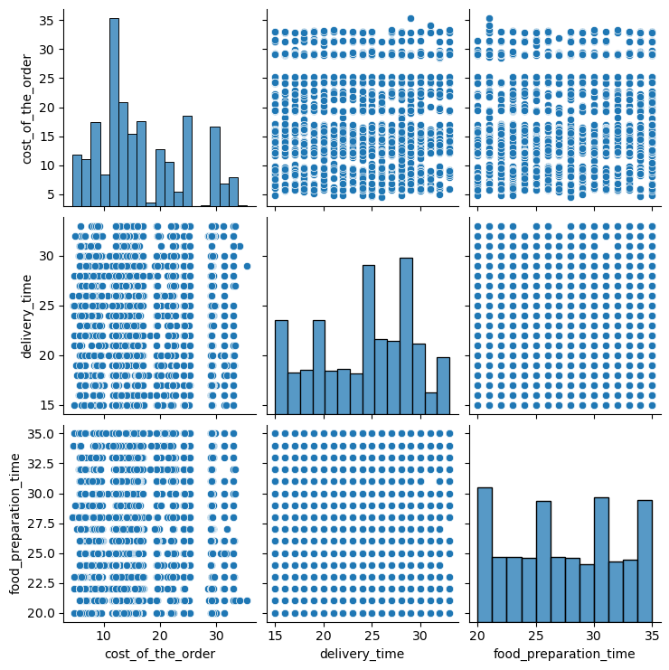

```python
plt.figure(figsize=(5,5))
sns.pairplot(data=df[['cost_of_the_order','delivery_time','food_preparation_time']])
plt.show()
```

- There is no relationship between numerical columns.

#### restaurant_name and customer

```
customer_with_no_of_orders         Low    Medium      High  Very High
restaurant_with_no_of_orders
Low                           0.210459  0.202186  0.198864   0.391304
Medium                        0.394133  0.394536  0.431818   0.434783
High                          0.146684  0.146448  0.142045   0.173913
Very High                     0.248724  0.256831  0.227273   0.000000
```

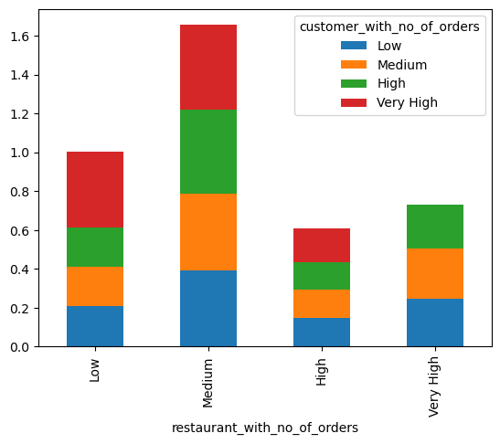

```python
# crosstab of categorical columns
crosstb = pd.crosstab(customer_restaurant_order_df['restaurant_with_no_of_orders'], customer_restaurant_order_df['customer_with_no_of_orders'], normalize='columns')
print(crosstb)
plt.figure(figsize=(4,3))
barplot = crosstb.plot.bar(stacked=True)
plt.show();
```

- Around 40% of customers from all categories prefer restaurants that has already served 10 to 50 orders, indicating most customers prefer to order from restaurants in this category(category name Medium).
- Around 39% of customers with more than 9 orders(very high order count category) prefer to order from restaurants with low number of orders l to 10, but there are only 2 customers in this category.
- Restaurants with order count 10 to 50 (category medium) are most prefered by customers(with respect to order count) followed by restaurants in low category(order count 1 to 10) with respect to number of orders.

#### restaurant, cost of the order and day of the week

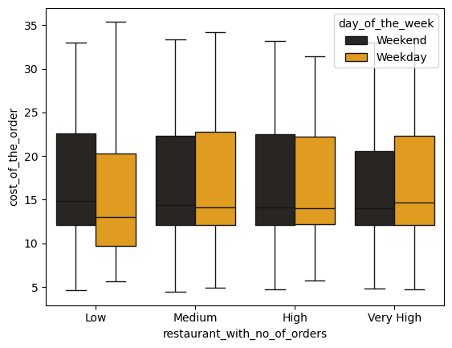

```python
# boxplot of  restaurant, cost of the order and day of the week
sns.boxplot(data=customer_restaurant_order_df, x='restaurant_with_no_of_orders', y='cost_of_the_order', color='orange', hue='day_of_the_week')
plt.show()
```

#### restaurant and rating

```
rating                               3         4         5
restaurant_with_no_of_orders
Low                           0.033563  0.056799  0.111015
Medium                        0.054217  0.139415  0.202238
High                          0.031842  0.053356  0.067986
Very High                     0.042169  0.082616  0.124785
```

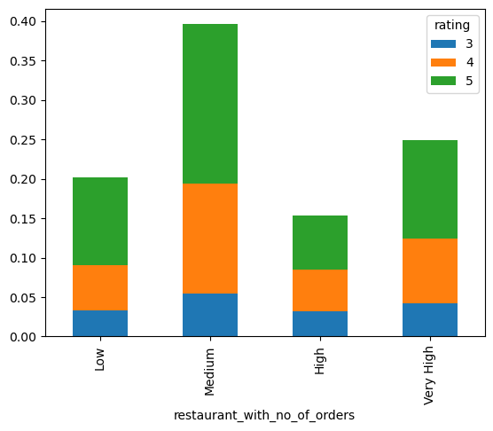

```python
# crosstab of categorical columns restaurant and rating
crosstb = pd.crosstab(customer_restaurant_order_df['restaurant_with_no_of_orders'], customer_restaurant_order_df['rating'],normalize=True)
print(crosstb)
plt.figure(figsize=(4,3))
barplot = crosstb.plot.bar(stacked=True)
plt.show();
```

- Most restaurants with medium(10 to 50) number of orders have rating of 4 and 5, indicating restaurants in edium category are doing well.

#### restaurant and cuisine

```
cuisine_type                  American  Chinese  French  Indian  Italian  \
restaurant_with_no_of_orders
Low                                 95       42       8      30       55
Medium                             154       59      10      43       63
High                                96      114       0       0       68
Very High                          239        0       0       0      112

cuisine_type                  Japanese  Korean  Mediterranean  Mexican  \
restaurant_with_no_of_orders
Low                                 51      13             21       25
Medium                             300       0             25       52
High                                 0       0              0        0
Very High                          119       0              0        0

cuisine_type                  Middle Eastern  Southern  Spanish  Thai  \
restaurant_with_no_of_orders
Low                                       13         3       12    19
Medium                                    36        14        0     0
High                                       0         0        0     0
Very High                                  0         0        0     0

cuisine_type                  Vietnamese
restaurant_with_no_of_orders
Low                                    7
Medium                                 0
High                                   0
Very High                              0
```

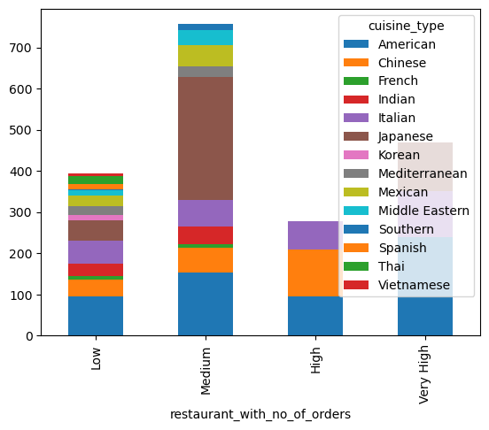

```python
# crosstab of categorical columns restaurant and cuisine
crosstb = pd.crosstab(customer_restaurant_order_df['restaurant_with_no_of_orders'], customer_restaurant_order_df['cuisine_type'])
print(crosstb)
plt.figure(figsize=(4,3))
barplot = crosstb.plot.bar(stacked=True)
plt.show();
```

#### restaurant, delivery_time and day of the week

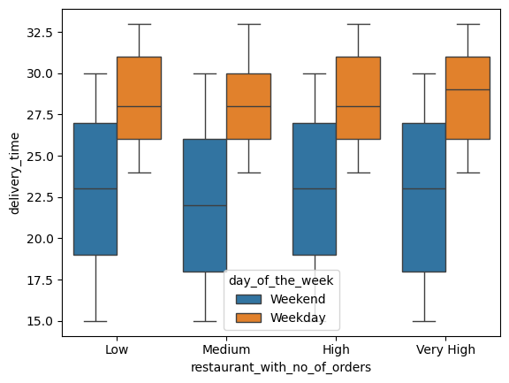

```python
# boxplot of restaurant, delivery_time and day of the week
sns.boxplot(data=customer_restaurant_order_df, x='restaurant_with_no_of_orders', y='delivery_time', hue='day_of_the_week')
plt.show()
```

- For most restaurants delivery time during weekend varies between 18 to 27 minutes 50% of the time.
- However during weekdays delivery time varies between 26 to 31 minutes 50% of the time, which is a bit higher than delivery time during weekends.

### **Question 13:** The company wants to provide a promotional offer in the advertisement of the restaurants. The condition to get the offer is that the restaurants must have a rating count of more than 50 and the average rating should be greater than 4. Find the restaurants fulfilling the criteria to get the promotional offer.

```python
# As rating data was imputed with mode we may not get correct output so using unimputed data
# consider only those records with rating given
df_cleaned = df[df['rating'] != 'Not given']

# convert rating column to numeric column so that we can find average rating
df_cleaned['rating'] = pd.to_numeric(df_cleaned['rating'], errors='coerce')

rating_counts = df_cleaned.groupby('restaurant_name')['rating'].count()

avg_ratings = df_cleaned.groupby('restaurant_name')['rating'].mean()

eligible = rating_counts[(rating_counts > 50) & (avg_ratings > 4)]
eligible
```

```
restaurant_name
Blue Ribbon Fried Chicken     64
Blue Ribbon Sushi             73
Shake Shack                  133
The Meatball Shop             84
Name: rating, dtype: int64
```

```python
# just wanted to know if same restaurant names turn up with imputed data as well

df_new = df_complete.copy()

# convert rating column to numeric column so that we can find average rating
df_new['rating'] = pd.to_numeric(df_new['rating'], errors='coerce')

# function to find out if rating count is more than 50
def rating_count_more_than_fifty_new(group):
    # Calculate the number of ratings
    rating_count = group['rating'].count()
    return rating_count > 50

# highly_rated is a Series object reset_index function will convert it into dataframe
highly_rated_new = df_new.groupby(['restaurant_name']).apply(rating_count_more_than_fifty_new)

# highly_rated is a Series object reset_index function will convert it into dataframe
df_highly_rated_new = highly_rated_new.reset_index()
df_highly_rated_new.columns='restaurant_name','rating_count_more_than_fifty'

# merging df_highly_rated with df_cleaned to get complete picture
df_highly_rated_new = df_highly_rated_new.merge(df_new, on='restaurant_name')

# filter with rating_count_more_than_fifty = True
df_highly_rated_new = df_highly_rated_new[df_highly_rated_new['rating_count_more_than_fifty']]

# filter with mean of rating > 4
df_highly_rated_new.groupby(['restaurant_name'])['rating'].mean() > 4
```

```
restaurant_name
Blue Ribbon Fried Chicken    True
Blue Ribbon Sushi            True
Shake Shack                  True
The Meatball Shop            True
Name: rating, dtype: bool
```

```python
# we can do it in this way as well
valid_ratings = df_cleaned
rating_counts = valid_ratings.groupby('restaurant_name')['rating'].count()
avg_ratings = valid_ratings.groupby('restaurant_name')['rating'].mean()
eligible = rating_counts[(rating_counts > 50) & (avg_ratings > 4).reindex(rating_counts.index)].index
eligible
```

```
Index(['Blue Ribbon Fried Chicken', 'Blue Ribbon Sushi', 'Shake Shack',
       'The Meatball Shop'],
      dtype='object', name='restaurant_name')
```

#### Observations:

- Restaurants "Blue Ribbon Fried Chicken", "Blue Ribbon Sushi", "Shake Shack" and "The Meatball Shop" satisfy given conditions and should be given promotional offer.

### **Question 14:** The company charges the restaurant 25% on the orders having cost greater than 20 dollars and 15% on the orders having cost greater than 5 dollars. Find the net revenue generated by the company across all orders.

```python
revenue = 0

# filter records where cost_of_the_order > 20
df_order_cost_greater_than_twenty = df_complete[df_complete['cost_of_the_order'] > 20]

# create new column fill it with 25% revenue
df_order_cost_greater_than_twenty['order_cost_greater_than_twenty_revenue'] = df_order_cost_greater_than_twenty.apply(lambda x : 0.25 * x['cost_of_the_order'], axis=1)

# get sum of all revenue
revenue = df_order_cost_greater_than_twenty['order_cost_greater_than_twenty_revenue'].sum()

# filter records where cost_of_the_order <= 20 and >5
df_order_cost_six_to_twenty = df_complete[(df_complete['cost_of_the_order'] > 5)&(df_complete['cost_of_the_order'] <= 20)]

# create new column fill it with 15% revenue
df_order_cost_six_to_twenty['order_cost_six_to_twenty'] = df_order_cost_six_to_twenty.apply(lambda x : 0.15 * x['cost_of_the_order'], axis=1)

# get sum of all revenue
revenue = revenue + df_order_cost_six_to_twenty['order_cost_six_to_twenty'].sum()
revenue
```

```
6166.303
```

```python
# or we can do it in this way as well
def calculate_revenue(cost):
    if cost > 20:
        return cost * 0.25
    elif cost < 5:
        return 0
    else:
        return cost *0.15

df_complete['revenue'] = df_complete['cost_of_the_order'].apply(calculate_revenue)
df_complete['revenue'].sum()
```

```
6166.303
```

#### Observations:

- Net revenue generated by the company across all orders is 6166.30 dollers.

### **Question 15:** The company wants to analyze the total time required to deliver the food. What percentage of orders take more than 60 minutes to get delivered from the time the order is placed? (The food has to be prepared and then delivered.)

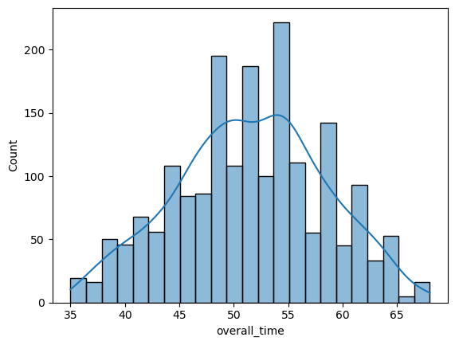

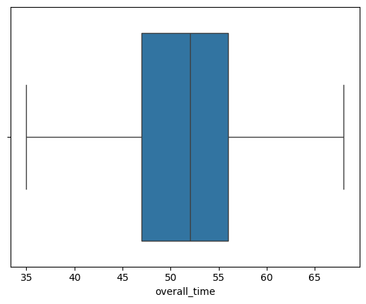

```
10.537407797681771
```

```python
# create a new column overall_time
df_complete['overall_time']= df_complete['delivery_time'] + df_complete['food_preparation_time']

sns.histplot(data=df_complete, x='overall_time', kde=True)
plt.show()

sns.boxplot(data=df_complete, x='overall_time')
plt.show()

# filter it with overall_time > 60
df_overall_time_greater_than_sixty = df_complete[df_complete['overall_time'] > 60]

# find percentage
percentage = (df_overall_time_greater_than_sixty.shape[0]/ df_complete.shape[0]) * 100
percentage
```

#### Observations:

- 10.53 % of orders take more than 60 minutes.
- There are no outliers in overall time.
- In general overall time taken to get food to customer once order is placed is between 47 to 56 minutes 50% of the time.

### **Question 16:** The company wants to analyze the delivery time of the orders on weekdays and weekends. How does the mean delivery time vary during weekdays and weekends?

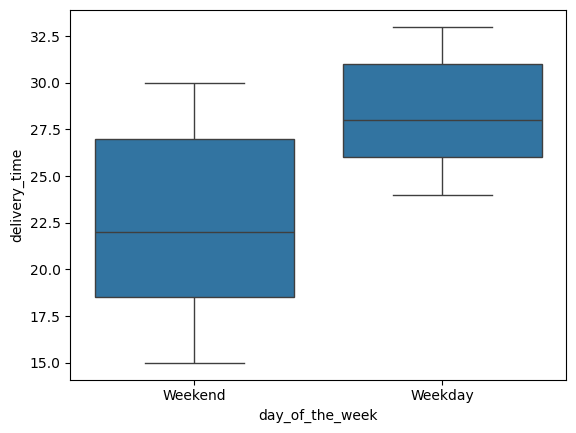

```python
# boxplot of delivery_time and day_of_the_week
sns.boxplot(data=df_complete, y='delivery_time', x='day_of_the_week')
plt.show()
```

```python
df_complete.groupby(['day_of_the_week'])['delivery_time'].mean()
```

```
day_of_the_week
Weekday    28.340037
Weekend    22.470022
Name: delivery_time, dtype: float64
```

```python
# calculating diffrence to find how much minutes difference is there
28.340037-22.470022
```

```
5.870014999999999
```

#### Observations:

- The mean delivery time during weekdays is higher (28.34 minutes) than mean delivery time during weekends (22.47 minutes) by 6 minutes.

### Recommendations:

- As the objective is to get fair idea about the demand of different restaurants which will help the company enhance customer experience.
- Restaurants in medium category have maximum total number of orders.
- Also 40% of customers across all categories prefer restaurants from medium category.
- I recommend restaurants in medium(order count 10 to 49) category which will help the company enhance customer experience.
- Like if the app displays restaurants in medium category which already recieved more orders than other categories having american and japanese cuisine type that has rating of 5 in its home page, it will definitely enhance customer experience.
- Lets find out those restaurant names.

```python
# consider only those records with rating given
df_cleaned = df[df['rating'] != 'Not given']

# convert rating column to numeric column so that we can find average rating
df_cleaned['rating'] = pd.to_numeric(df_cleaned['rating'], errors='coerce')

# find restaurants in medium category
order_count = df_cleaned.groupby(['restaurant_name'])['order_id'].count()
df_medium = order_count[(order_count<49)&(order_count>9)].reset_index()
df_medium.columns = ['restaurant_name', 'order_count']
df_medium_all = df_medium.merge(df_cleaned, on='restaurant_name')
# find restaurants that serve 'American', 'Japanese' cuisine.
mask = df_medium_all['cuisine_type'].isin(['American', 'Japanese'])

# Apply the mask to filter the DataFrame
df_medium_cousine = df_medium_all[mask]

# find most popular restaurants
# Calculate average ratings and rating counts, resetting the index
medium_cousine_avg_ratings = df_medium_cousine.groupby('restaurant_name')['rating'].mean().reset_index()
medium_cousine_rating_counts = df_medium_cousine.groupby('restaurant_name')['rating'].count().reset_index()

# Merge the average ratings and rating counts back into df_medium_cousine
df_medium_cousine = df_medium_cousine.merge(medium_cousine_avg_ratings, on='restaurant_name')
df_medium_cousine = df_medium_cousine.merge(medium_cousine_rating_counts, on='restaurant_name')

# find recomended restaurants
eligible_restaurants = df_medium_cousine[(df_medium_cousine['rating_y'] > 4) & (df_medium_cousine['rating_x'] > 4)]
eligible_restaurants['restaurant_name'].unique()
```

```
array(['Bareburger', 'Blue Ribbon Sushi Bar & Grill',
       'Blue Ribbon Sushi Izakaya', 'Five Guys Burgers and Fries',
       'J. G. Melon', 'Momoya', 'Nobu Next Door', "P.J. Clarke's",
       'Sushi of Gari 46', 'Sushi of Gari Tribeca', 'TAO', 'The Smile'],
      dtype=object)
```

```python
from google.colab import drive
drive.mount('/content/drive')
```

Below restaurants are recomended to be shown in home screen for ease of access to customer to choose restaurant, this will enhance customer experience.

- 'Bareburger', 'Blue Ribbon Sushi Bar & Grill', 'Blue Ribbon Sushi Izakaya', 'Five Guys Burgers and Fries', 'J. G. Melon', 'Momoya', 'Nobu Next Door', "P.J. Clarke's", 'Sushi of Gari 46', 'Sushi of Gari Tribeca', 'TAO', 'The Smile'